# Text analysis of the eligible papers included in the scoping review

Carlos Granell

Universitat Jaume I, Spain

31 agosto, 2020

Abstract

This analysis generate tables and figures related to the bibliographic data of the eligible papers in the review. It is a collaborative research activity as part of the [IDEAIS project](http://www.redideais.net/).

# 1 Required libraries

```r
library(here)
library(tidyverse)
library(tidytext)
library(stringr)
library(kableExtra)
library(wordcloud)
library(quanteda)

# for deterministic cloud rendering
set.seed(nchar("IDEAIS - scoping review paper"))
```

# 2 Data

In total, 37 papers were eligible (N=37). Some of the eligibible papers may not be openly available due to access restriction imposed by publishers. Therefore, the content of the papers is not provided in this repository. We indeed include the bibliographic information of each paper in the file papers2010_2019, in the directory `data`.

# 3 Analysis

## 3.1 Table 1. Conferences and journals

Table 1 (Conferences and journals) was manualy created based on the tables below. The first table shows the conferences/journals per year. The second table shows the percentage distribution of conference papers and journal articles.

| Type | Year | Source | # |
| --- | --- | --- | --- |
| Conference paper | 2010 | Proceedings of the Workshop on Computational Models of Spatial Language Interpretation | 1 |
|  |  | Trends in Practical Applications of Agents and Multiagent Systems | 1 |
|  | 2011 | Twelfth Annual Conference of the International Speech Communication Association | 1 |
|  | 2012 | International Workshop on Place-related Knowledge Acquisition Research | 1 |
|  | 2015 | Proceedings of the 6th International Conference on Software Development and Technologies for Enhancing Accessibility and Fighting Info-exclusion | 1 |
|  | 2017 | IEEE International Conference on Acoustics, Speech and Signal Processing | 1 |
|  |  | Proc. Interspeech 2017 | 1 |
|  | 2018 | 22nd International Conference Information Visualisation | 1 |
|  |  | 23rd International Conference on Intelligent User Interfaces | 1 |
|  |  | 27th IEEE International Symposium on Robot and Human Interactive Communication | 1 |
|  |  | 8th IEEE International Conference on Cognitive Infocommunications | 1 |
|  |  | Construction Research Congress 2018 | 1 |
|  |  | Forum for Information Retrieval Evaluation | 2 |
|  |  | INTED2018 Proceedings | 1 |
|  |  | International Conference on Internet Science | 1 |
|  |  | Proceedings of the 20th ACM International Conference on Multimodal Interaction | 1 |
|  | 2019 | International Conference on Human-Computer Interaction | 2 |
|  |  | Proceedings of the 19th International Workshop of Physical Agents | 1 |
|  |  | Proceedings of the 27th Italian Symposium on Advanced Database Systems | 1 |
|  |  | Proceedings of the 32nd International Conference on Computer Animation and Social Agents | 1 |
|  |  | Proceedings of the 5th ACM Workshop on Mobile Systems for Computational Social Science | 1 |
|  | 2020 | The Annual International Conference on Geographic Information Science | 1 |
| Journal paper | 2011 | Journal of Visual Languages & Computing | 1 |
|  | 2013 | Transactions in GIS | 1 |
|  | 2015 | International Journal of Serious Games | 1 |
|  | 2016 | Journal of Network and Computer Applications | 1 |
|  | 2017 | Computer Science and Information Systems | 1 |
|  | 2018 | Computers, Environment and Urban Systems | 1 |
|  | 2019 | ACM Transactions on Interactive Intelligent Systems | 1 |
|  |  | Engineering Applications of Artificial Intelligence | 1 |
|  |  | Information | 1 |
|  |  | International Journal of Innovative Technology and Exploring Engineering | 1 |
|  |  | Journal of Navigation | 1 |
|  |  | Sensors and Materials | 1 |
|  |  | Water | 1 |

| Type of document | N | % |
| --- | --- | --- |
| Conference paper | 24 | 65% |
| Journal paper | 13 | 35% |

## 3.2 Figure 2. Temporal distribution of eligibible papers

[figure not shown]

## 3.3 Terms frequency analysis

As part of the text analysis of papers, including wordcloud and terms frequency analysis, we read the full list of abstracts from the `papers` and process them to create a [tidy](https://www.jstatsoft.org/article/view/v059i10) data structure without [stop words](https://en.wikipedia.org/wiki/Stop_words). The stop words include specific words, such as `paper` and `authors`, which are included in many abstract, abbreviations such as `e.g.`, and terms particular to scientific articles, such as `summary`. Also all numeric literas are removed from the word list. Reference book to text mining in tidy format: [Text Mining with R](https://www.tidytextmining.com/)

About 50 % (3585) of the total words (7112) in all abstracts are considered non stop words.

*How many non-stop words does each abstract have?*

Abstracts ordered by number of words after removal of stopwords.

| id | year | # non-stop words |
| --- | --- | --- |
| 056 | 2019 | 190 |
| 054 | 2015 | 158 |
| 040 | 2019 | 150 |
| 004 | 2019 | 145 |
| 010 | 2018 | 138 |
| 001 | 2018 | 129 |
| 046 | 2018 | 126 |
| 048 | 2017 | 120 |
| 012 | 2019 | 119 |
| 020 | 2019 | 113 |
| 021 | 2019 | 113 |
| 026 | 2018 | 113 |
| 024 | 2018 | 109 |
| 053 | 2018 | 107 |
| 035 | 2013 | 102 |
| 045 | 2017 | 102 |
| 050 | 2019 | 101 |
| 047 | 2015 | 100 |
| 015 | 2018 | 99 |
| 058 | 2016 | 99 |
| 049 | 2019 | 96 |
| 043 | 2018 | 85 |
| 038 | 2019 | 83 |
| 011 | 2018 | 82 |
| 057 | 2011 | 74 |
| 008 | 2019 | 69 |
| 018 | 2012 | 69 |
| 016 | 2019 | 66 |
| 044 | 2017 | 66 |
| 027 | 2018 | 64 |
| 039 | 2011 | 64 |
| 014 | 2018 | 63 |
| 025 | 2010 | 62 |
| 101 | 2019 | 62 |
| 041 | 2020 | 59 |
| 037 | 2010 | 57 |
| 007 | 2019 | 31 |

*How many non-stop words does each year have?*

Total number of words after removal of stopwords per year.

| year | # non-stop words |
| --- | --- |
| 2019 | 1338 |
| 2018 | 1115 |
| 2017 | 288 |
| 2015 | 258 |
| 2011 | 138 |
| 2010 | 119 |
| 2013 | 102 |
| 2016 | 99 |
| 2012 | 69 |
| 2020 | 59 |

## 3.4 Top wordstems and wordstem clouds

The following table are based on word stems extracted with a stemming algorithm from package [`quanteda`](https://cran.r-project.org/package=quanteda). It shows shows the number of occurrences of the 100 most frequent wordstems in all abstracts.

Most frequent wordstems.

| place | wordstem | n | # abstracts / wordstem |
| --- | --- | --- | --- |
| 1 | inform | 67 | 26 |
| 2 | system | 66 | 26 |
| 3 | user | 63 | 27 |
| 4 | interact | 41 | 21 |
| 5 | data | 40 | 16 |
| 6 | convers | 38 | 26 |
| 7 | languag | 31 | 13 |
| 8 | navig | 31 | 9 |
| 9 | agent | 30 | 14 |
| 10 | assist | 30 | 14 |
| 11 | virtual | 29 | 11 |
| 12 | locat | 27 | 21 |
| 13 | robot | 24 | 7 |
| 14 | task | 23 | 12 |
| 15 | human | 22 | 15 |
| 16 | model | 22 | 12 |
| 17 | object | 22 | 6 |
| 18 | spatial | 22 | 11 |
| 19 | environ | 20 | 12 |
| 20 | interfac | 20 | 11 |
| 21 | mobil | 20 | 8 |
| 22 | knowledg | 19 | 11 |
| 23 | learn | 19 | 12 |
| 24 | game | 18 | 3 |
| 25 | entiti | 17 | 4 |
| 26 | provid | 17 | 14 |
| 27 | natur | 16 | 10 |
| 28 | servic | 16 | 9 |
| 29 | studi | 16 | 13 |
| 30 | applic | 15 | 7 |

[output cut: 70 more lines]

### 3.4.1 Figure 3. Word cloud of the most frequent word sterms + frequency bar chart

Left side of the figure shows a cloud which includes word stems that occur at least 5 times. The cloud has a maximum of 100 words. Right side shows a frequency bar chart of the top 15 word stems. Colours are in sync in both charts.

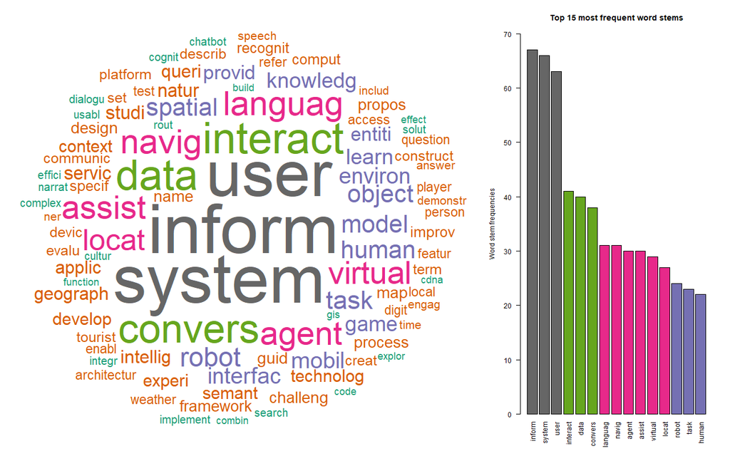